# *RMeDPower2*: helping design and analyses of data from repeated measures experiments

## 2.3 Behavior assays

Morris Water Maze (MWM) is an assay used to test spatial learning in animal models of diseases like Alzheimer’s disease. The time recorded by each mouse to reach a target region (in the MWM) over multiple trials denoted as latency is the response of interest. Mouse models deficient in spatial learning would demonstrate an increased latency to reach a target region (invisible platform in Figure 3) across the learning trials.

[figure not shown]

Figure 3: Morris Water Maze

```r
template_dir <- "~/Dropbox (Gladstone)/calcPower f1000_manuscript/Final_paper_materials/Revisions/input_templates/behavior_data/"
data <- read.csv(paste0(template_dir, "MWM_data.csv"), header = T)
design <- readDesign(paste0(template_dir,"design_behavior.json"))
model <- readProbabilityModel(paste0(template_dir,"prob_model.json"))
power_param <- readPowerParams(paste0(template_dir,"power_param.json"))
```

```r
diagnose_res <- diagnoseDataModel(data, design, model)
```

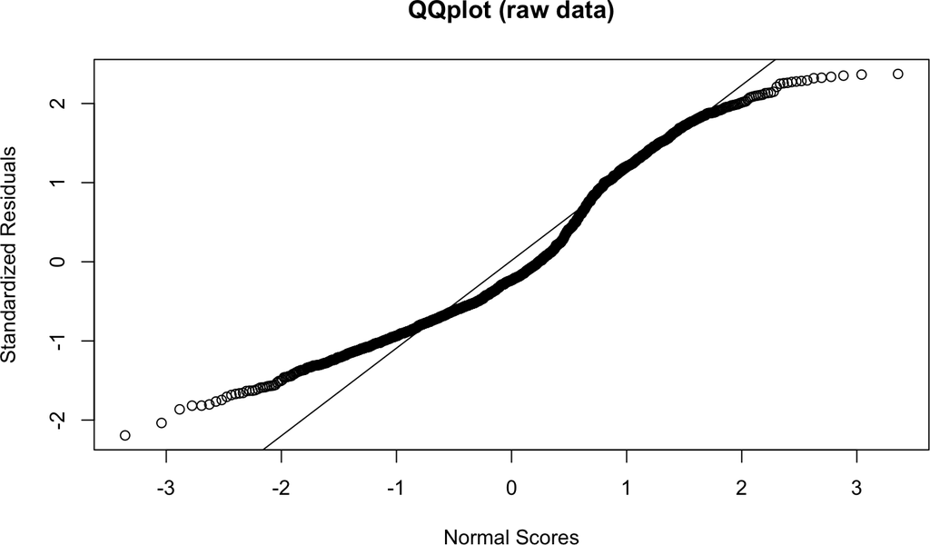

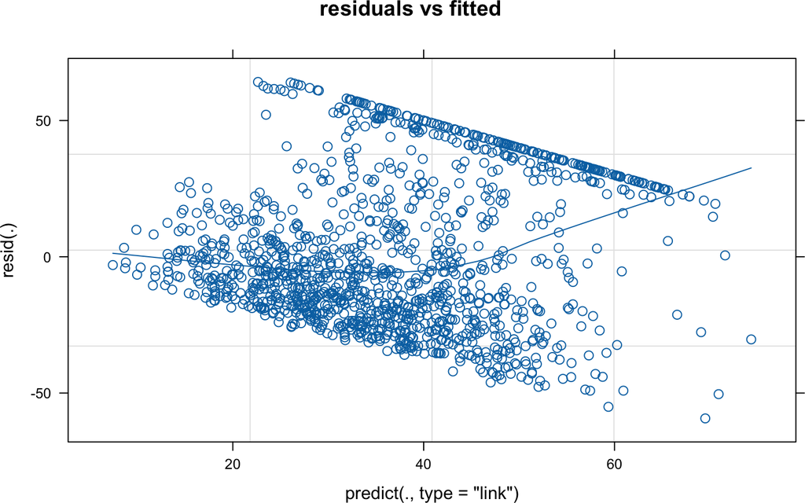

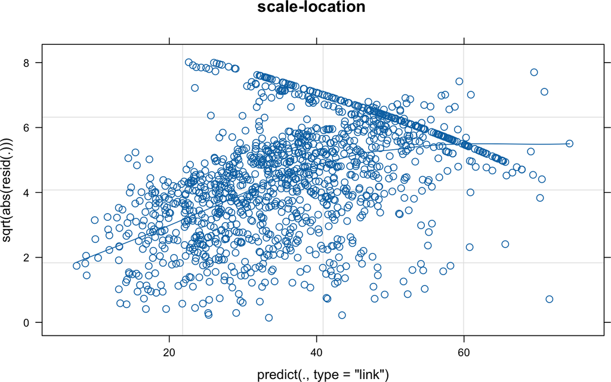

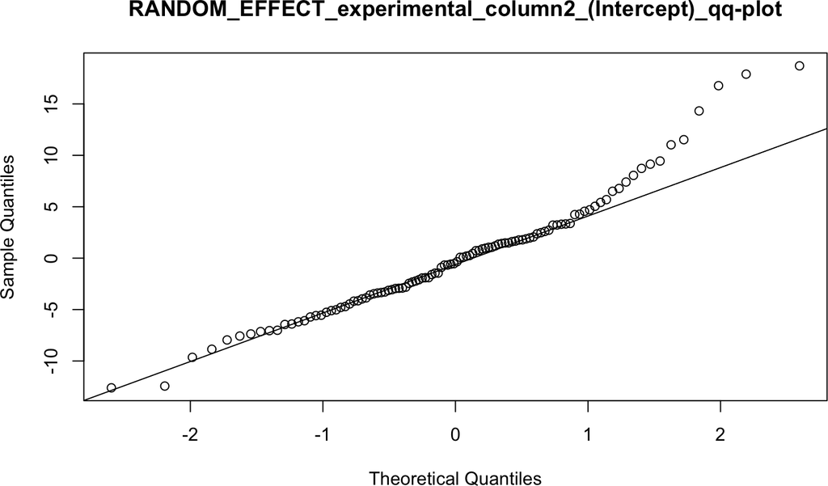

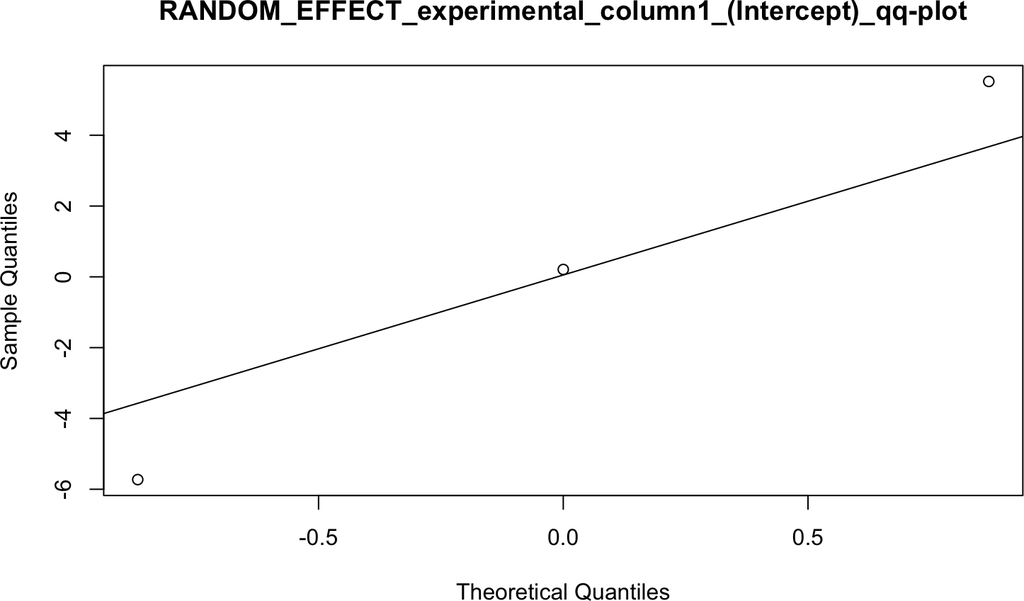

```
## [1] "No outlier detected from the raw Data"
```

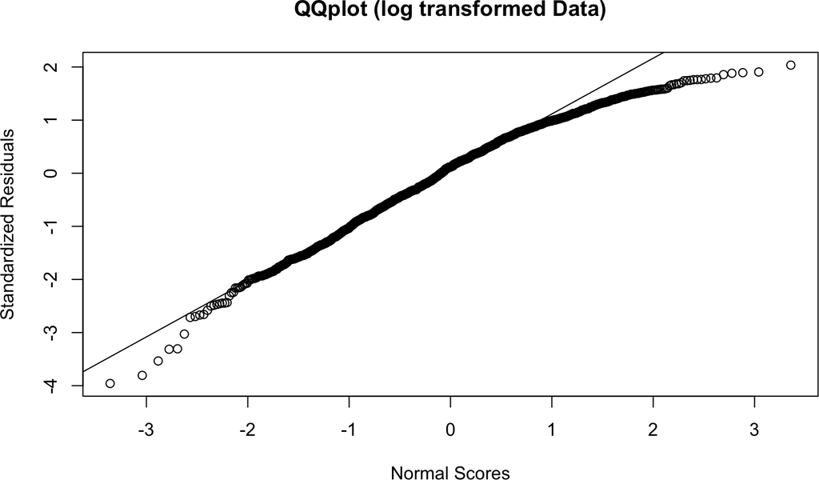

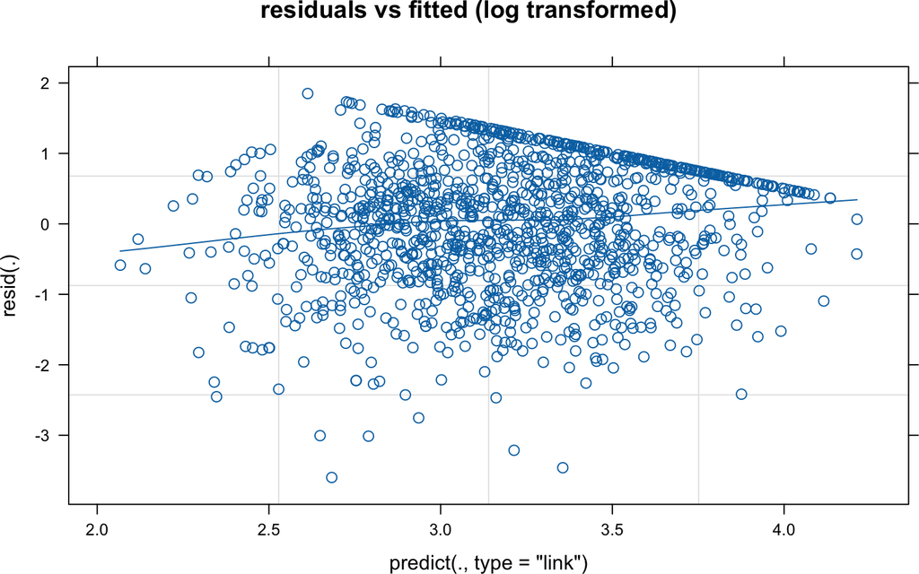

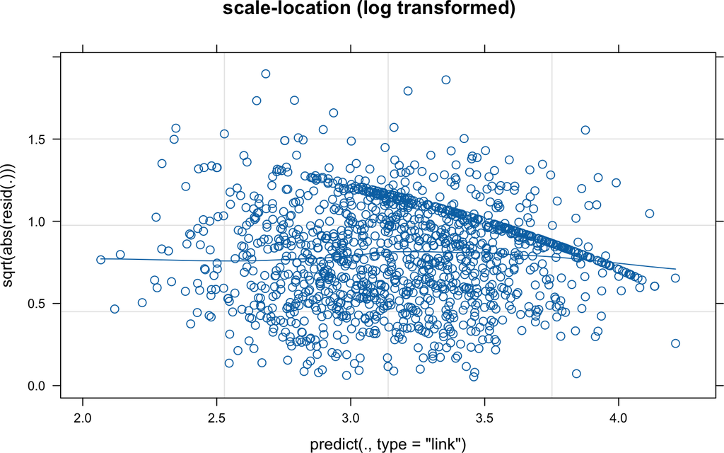

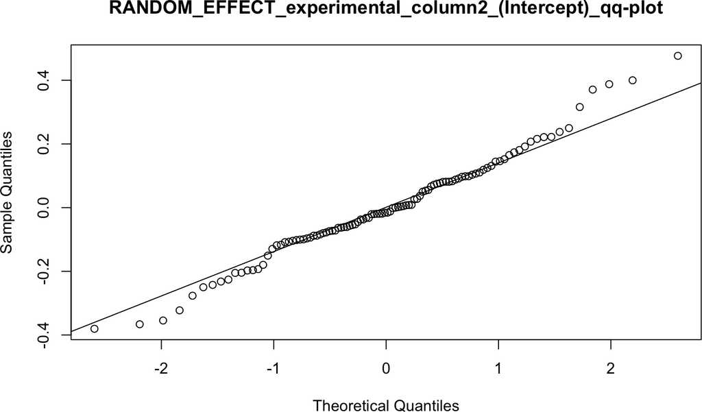

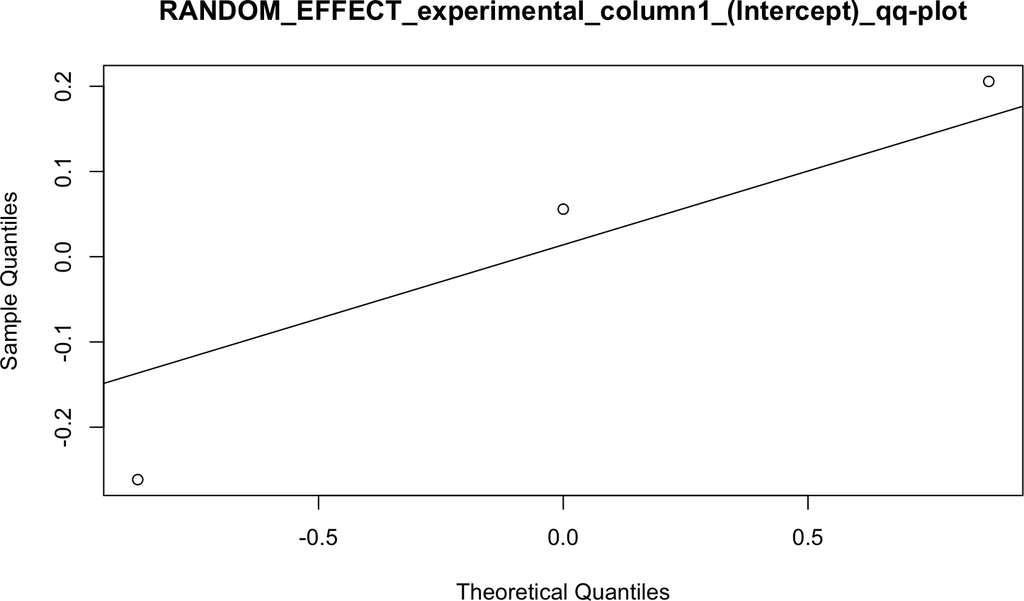

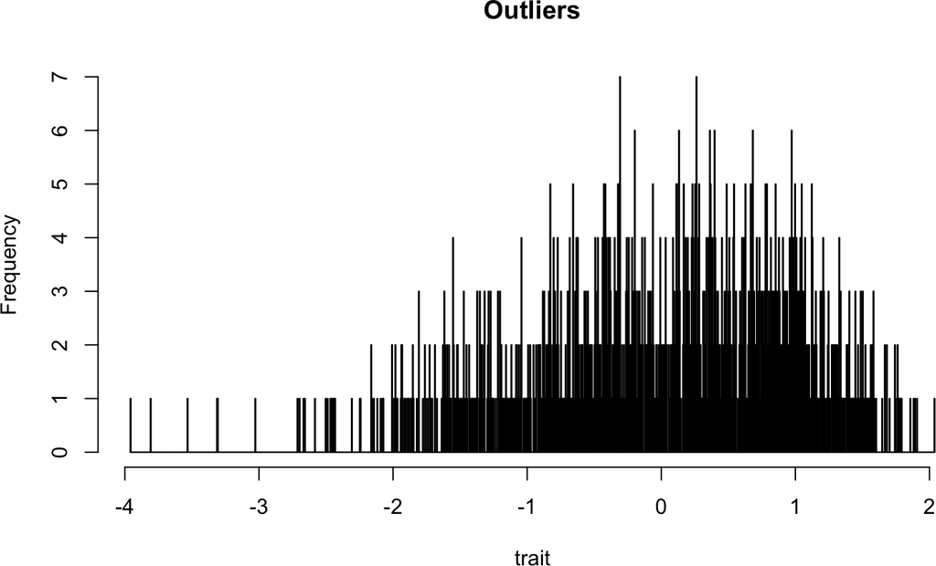

Based on the above plots, it seems like the log transformed versions of the latency responses better fit the model assumptions. Therefore using these transformed responses we will estimate and visualize our parameter of interest.

```r
data_update <- diagnose_res$Data_updated
design_update <- design
design_update@response_column %<>% paste0(., "_logTransformed")
estimate_res <- getEstimatesOfInterest(data_update, design_update, model)
```

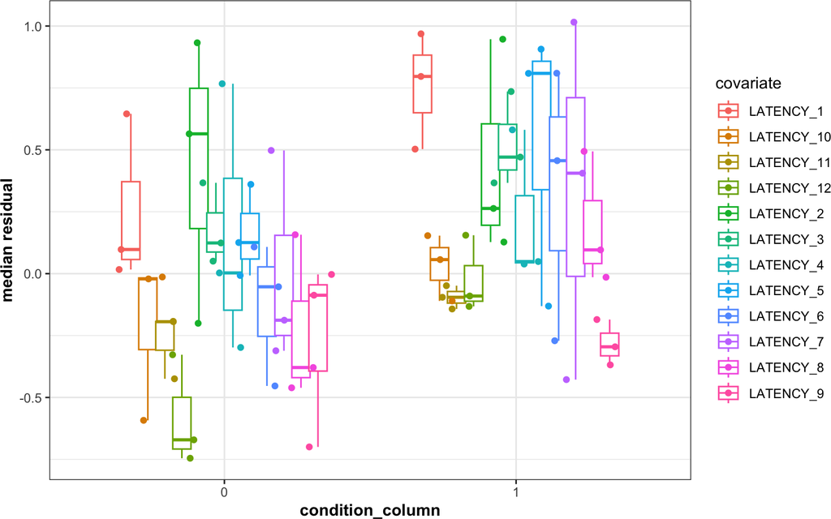

```r
print(estimate_res[[1]])
```

```
## Linear mixed model fit by REML. t-tests use Satterthwaite's method [
## lmerModLmerTest]
## Formula:
## response_column ~ condition_column + covariate + (1 | experimental_column1) +
##     (1 | experimental_column2)
##    Data: fixed_global_variable_data
##
## REML criterion at convergence: 3464.4
##
## Scaled residuals:
##     Min      1Q  Median      3Q     Max
## -3.9587 -0.6407  0.1179  0.7752  2.0354
##
## Random effects:
##  Groups               Name        Variance Std.Dev.
##  experimental_column2 (Intercept) 0.05842  0.2417
##  experimental_column1 (Intercept) 0.06049  0.2460
##  Residual                         0.82664  0.9092
## Number of obs: 1272, groups:
## experimental_column2, 106; experimental_column1, 3
##
## Fixed effects:
##                       Estimate Std. Error         df t value Pr(>|t|)
## (Intercept)            3.40673    0.17276    3.84608  19.720 5.24e-05 ***
## condition_column1      0.37837    0.06975  102.13381   5.424 3.92e-07 ***
## covariateLATENCY_10   -0.46921    0.12489 1155.00012  -3.757 0.000181 ***
## covariateLATENCY_11   -0.64563    0.12489 1155.00012  -5.170 2.76e-07 ***
## covariateLATENCY_12   -0.69739    0.12489 1155.00012  -5.584 2.93e-08 ***
## covariateLATENCY_2    -0.07767    0.12489 1155.00012  -0.622 0.534093
## covariateLATENCY_3    -0.15209    0.12489 1155.00012  -1.218 0.223531
## covariateLATENCY_4    -0.41716    0.12489 1155.00012  -3.340 0.000864 ***
## covariateLATENCY_5    -0.27506    0.12489 1155.00012  -2.202 0.027828 *
## covariateLATENCY_6    -0.37621    0.12489 1155.00012  -3.012 0.002648 **
## covariateLATENCY_7    -0.32589    0.12489 1155.00012  -2.609 0.009185 **
## covariateLATENCY_8    -0.48713    0.12489 1155.00012  -3.901 0.000102 ***
## covariateLATENCY_9    -0.62461    0.12489 1155.00012  -5.001 6.57e-07 ***
## ---
## Signif. codes:  0 '***' 0.001 '**' 0.01 '*' 0.05 '.' 0.1 ' ' 1
```

We will also perform sample-size calculations for the number of mice needed per cohort.

```r
power_param@target_columns <- "MouseID"
power_res <- calculatePower(data_update, design_update, model, power_param)
```

[output not shown]

## 2.4 Brain electrical signal assays

Patch clamp is a technique that can be used to measure membrane action potential in excitable cells like neurons. We will work with (simulated) data from two sets of mice - one representing a Alzheimer’s Disease model (hAPP) and the other representing control or wild-type mice. In each of these mice, multiple brain tissue slices are isolated and the membrane action potential for at least one neuronal cell in each slice is recorded.

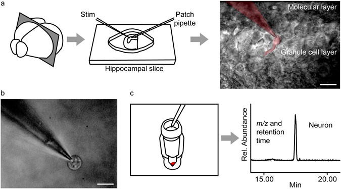

Figure 4: Patch clamp assay

```r
template_dir <- "~/Dropbox (Gladstone)/calcPower f1000_manuscript/Final_paper_materials/Revisions/input_templates/electrical_patch_clamp_data/"
data <- read.csv(paste0(template_dir, "patch_clamp_data.csv"), header = T)
head(data)
```

```
##   negative_action_potential_mV    Mice Genotype    Sex slice_number
## 1                     56.23547 Mouse_1     hAPP   Male            1
## 2                     47.89597 Mouse_3     hAPP   Male            1
## 3                     56.20910 Mouse_3     hAPP   Male            2
## 4                     53.14394 Mouse_9     hAPP Female            1
## 5                     53.67793 Mouse_9     hAPP Female            1
## 6                     61.21780 Mouse_9     hAPP Female            1
```

```r
design <- readDesign(paste0(template_dir,"design_patch_clamp.json"))
print(design)
```

```
## An object of class "RMeDesign"
## Slot "response_column":
## [1] "negative_action_potential_mV"
##
## Slot "covariate":
## NULL
##
## Slot "condition_column":
## [1] "Genotype"
##
## Slot "condition_is_categorical":
## [1] TRUE
##
## Slot "experimental_columns":
## [1] "Mice"         "slice_number"
##
## Slot "crossed_columns":
## NULL
##
## Slot "total_column":
## NULL
##
## Slot "outlier_alpha":
## [1] 0.05
##
## Slot "na_action":
## [1] "complete"
##
## Slot "include_interaction":
## [1] FALSE
##
## Slot "random_slope_variable":
## NULL
```

```r
model <- readProbabilityModel(paste0(template_dir,"prob_model.json"))
print(model)
```

```
## An object of class "ProbabilityModel"
## Slot "error_is_non_normal":
## [1] FALSE
##
## Slot "family_p":
## NULL
```

```r
power_param <- readPowerParams(paste0(template_dir,"power_param.json"))
print(power_param)
```

```
## An object of class "PowerParams"
## Slot "target_columns":
## [1] "Mice"
##
## Slot "power_curve":
## [1] 1
##
## Slot "nsimn":
## [1] 10
##
## Slot "levels":
## [1] 1
##
## Slot "max_size":
## [1] 1
##
## Slot "alpha":
## [1] 0.05
##
## Slot "breaks":
## NULL
##
## Slot "effect_size":
## NULL
##
## Slot "icc":
## NULL
```

We will now evaluate the model.

```r
diagnose_res <-diagnoseDataModel(data, design, model)
```

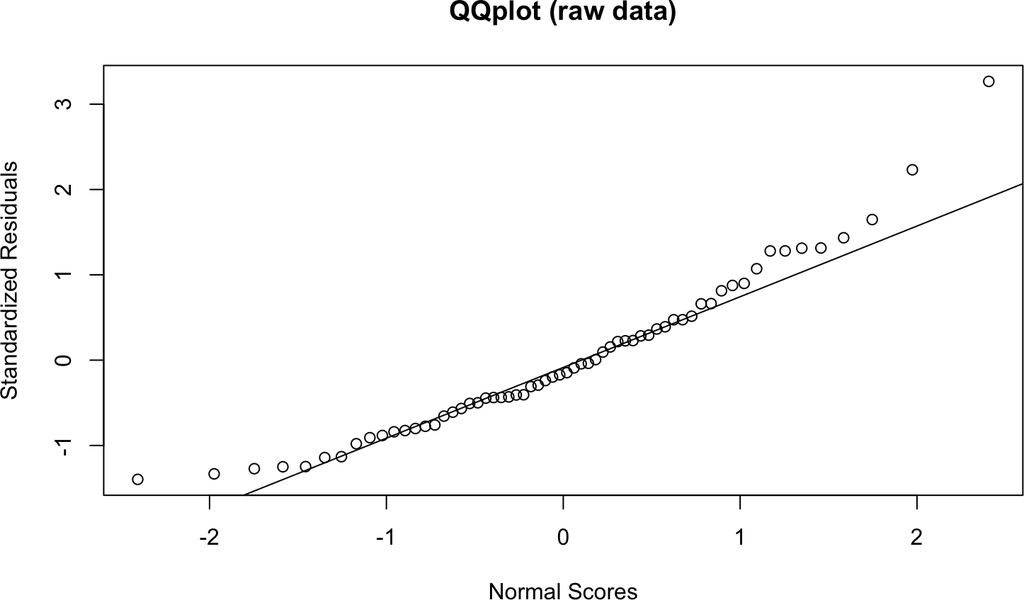

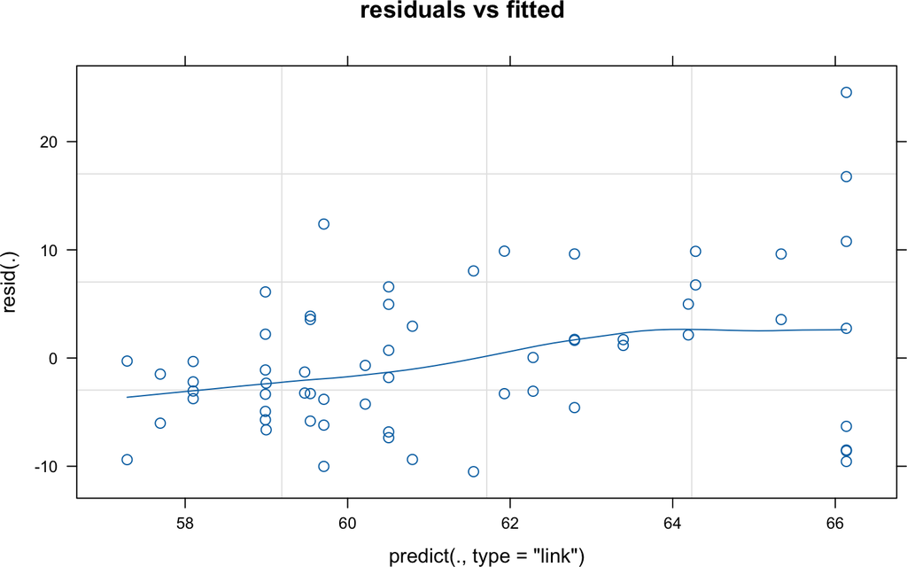

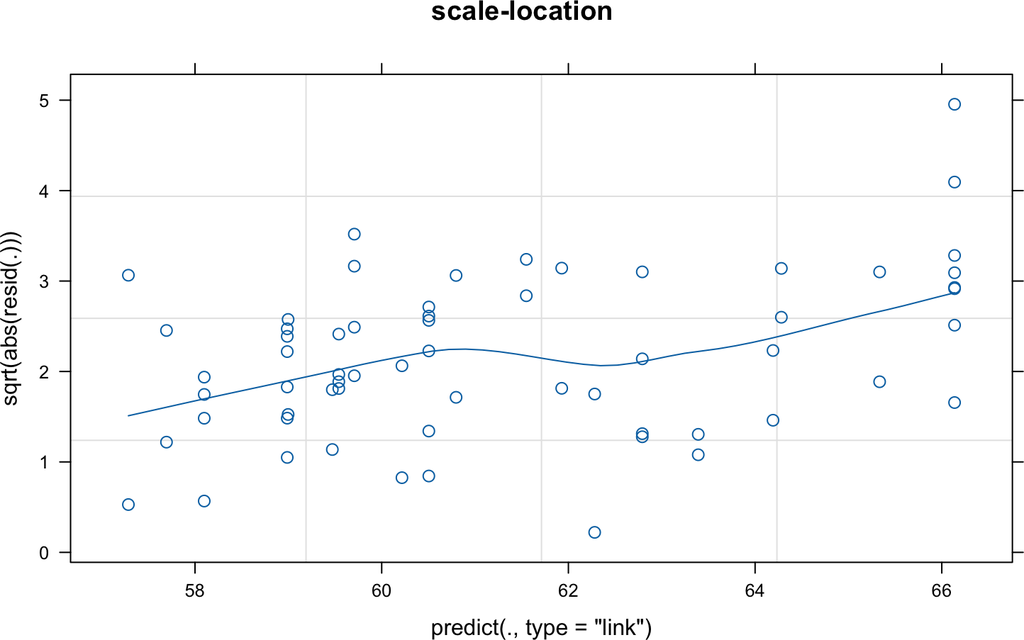

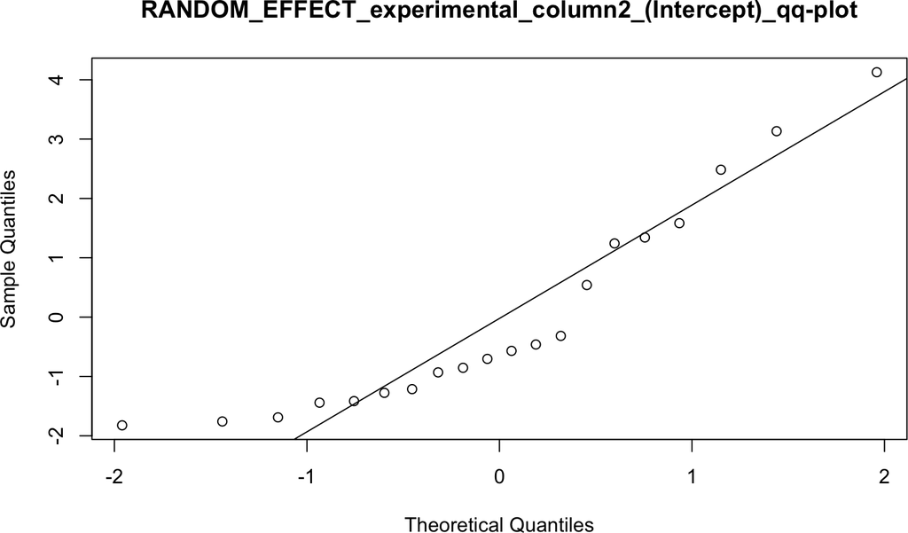

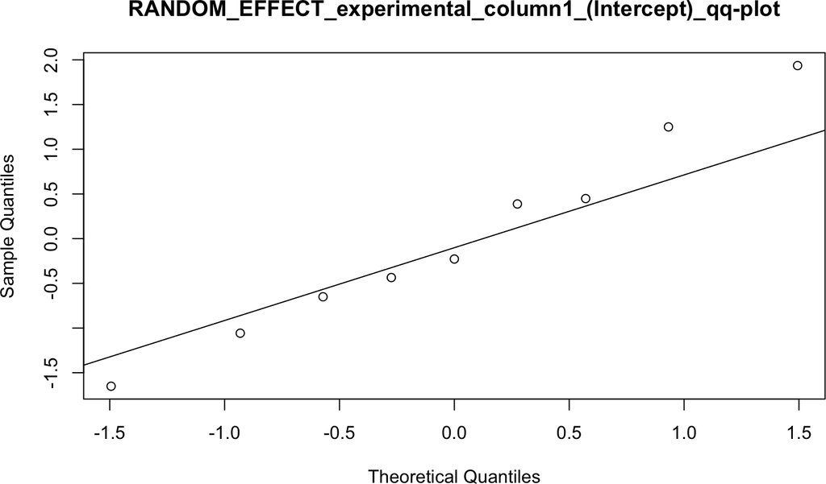

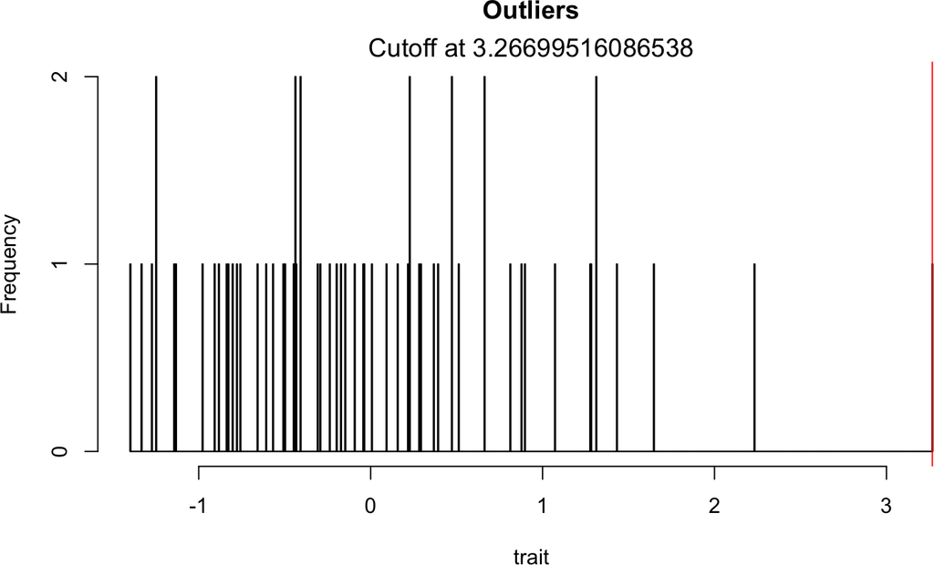

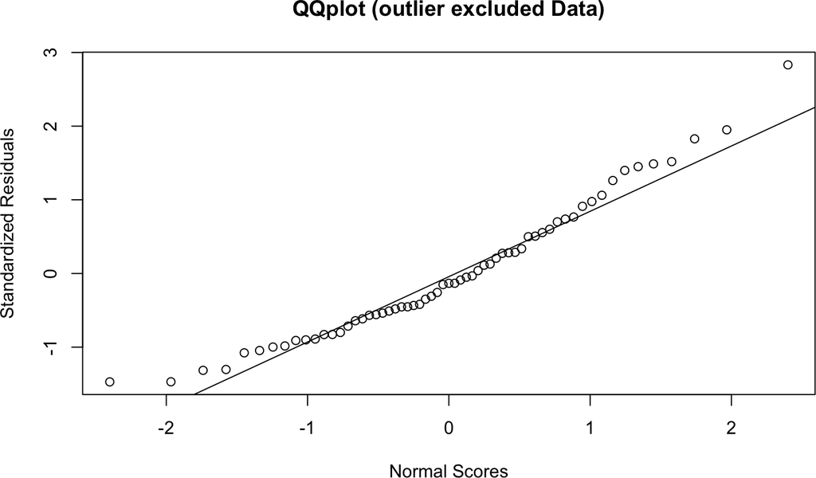

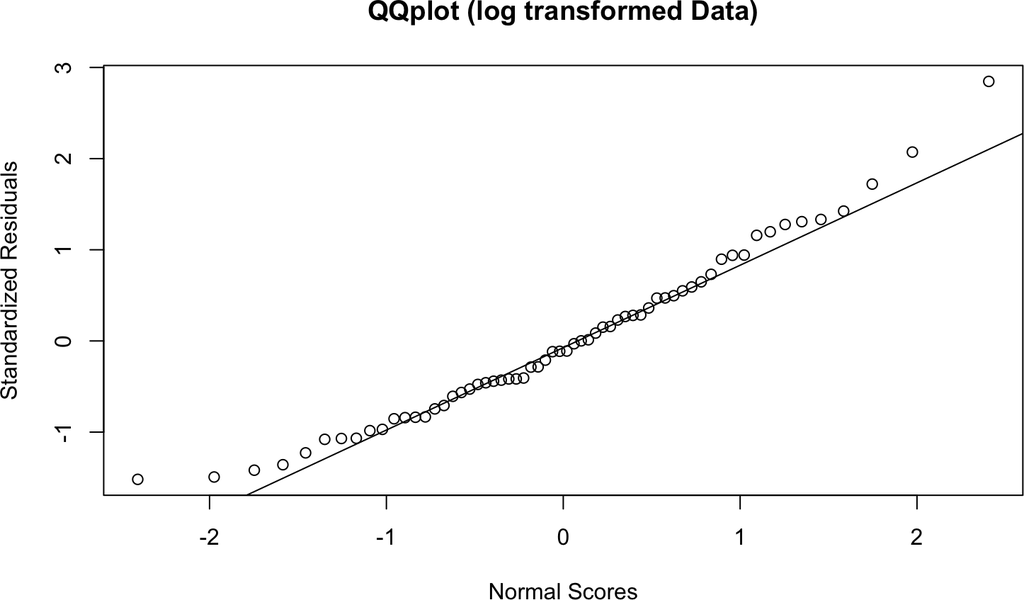

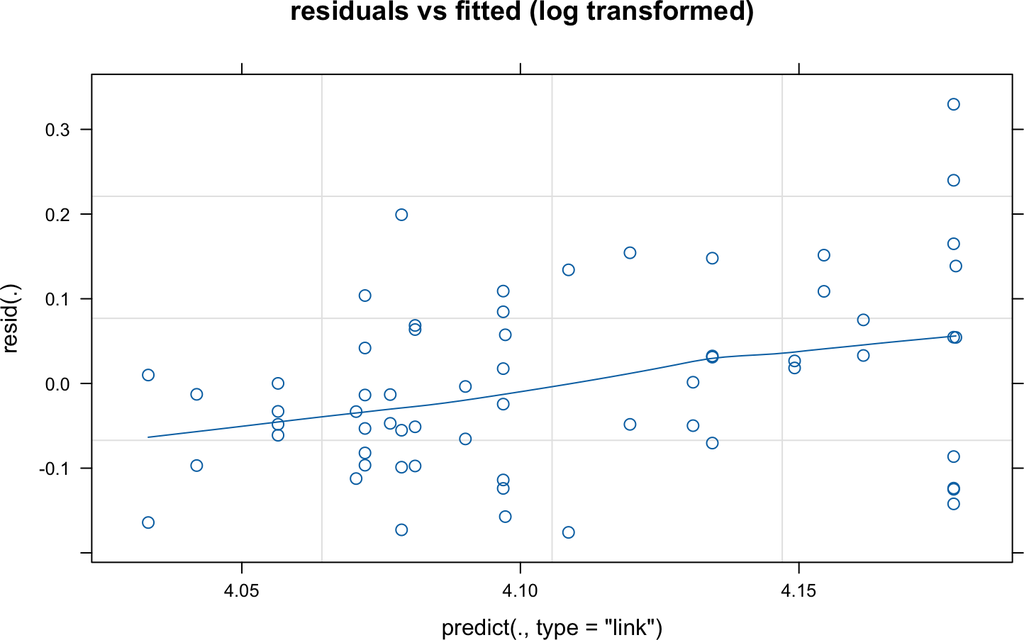

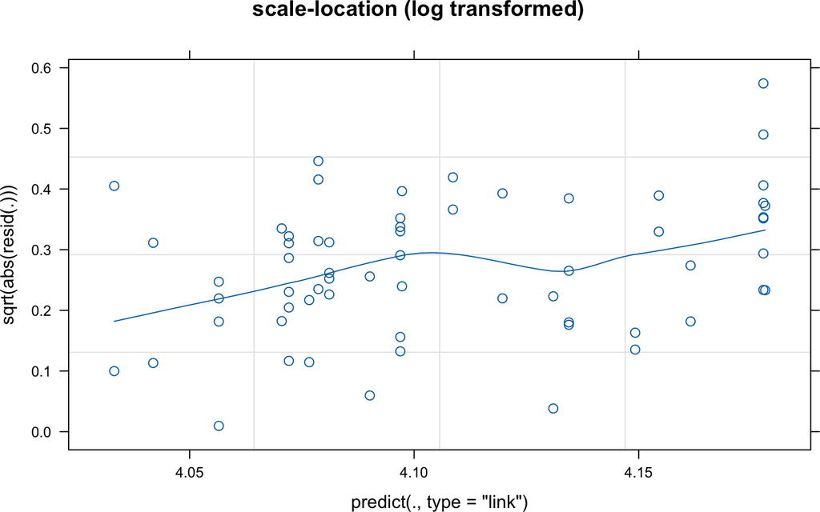

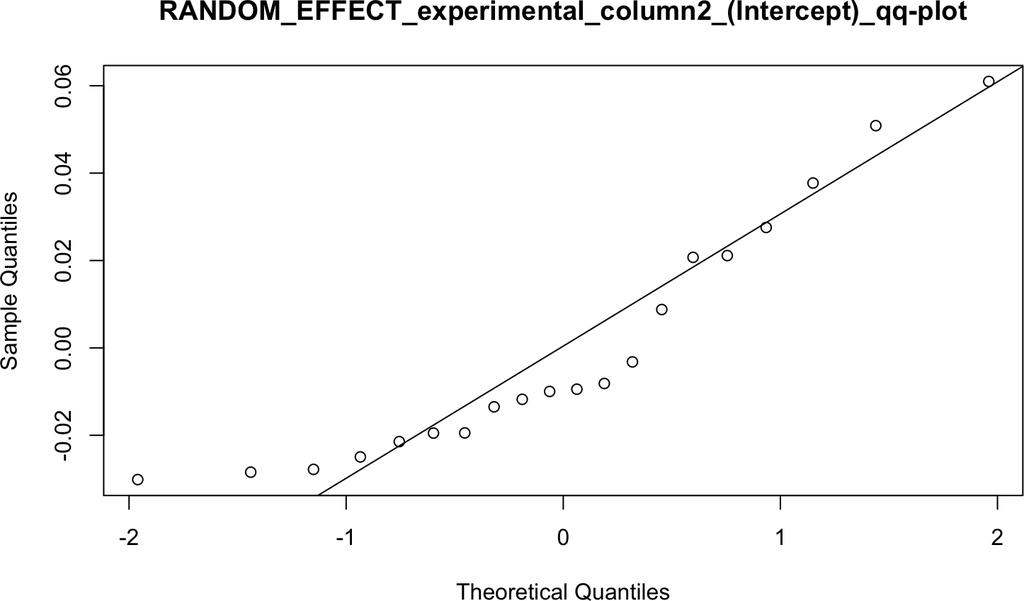

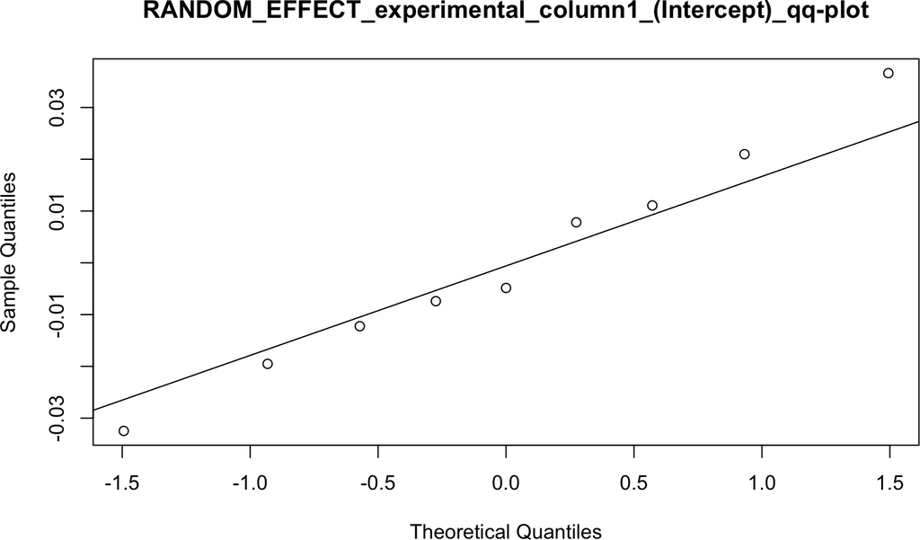

[1 more figures not shown]

It does not look like the log transformation resulted significantly changed how well the model assumptions were being met. We will estimate the association of genotype using the responses in their natural scale.

```r
estimate_res <- getEstimatesOfInterest(data, design, model)
```

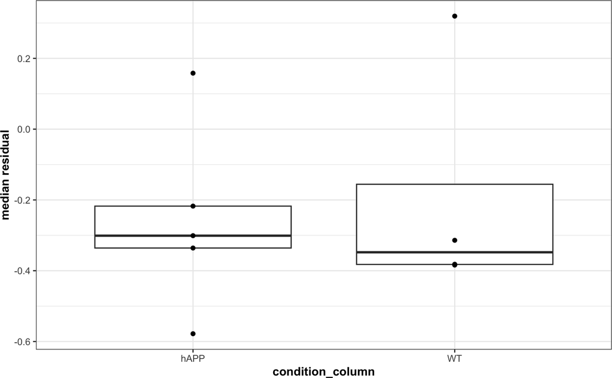

```r
print(estimate_res[[1]])
```

```
## Linear mixed model fit by REML. t-tests use Satterthwaite's method [
## lmerModLmerTest]
## Formula: response_column ~ condition_column + (1 | experimental_column1) +
##     (1 | experimental_column2)
##    Data: fixed_global_variable_data
##
## REML criterion at convergence: 429.2
##
## Scaled residuals:
##     Min      1Q  Median      3Q     Max
## -1.3970 -0.6443 -0.1594  0.4738  3.2670
##
## Random effects:
##  Groups               Name        Variance Std.Dev.
##  experimental_column2 (Intercept) 10.646   3.263
##  experimental_column1 (Intercept)  5.427   2.330
##  Residual                         56.462   7.514
## Number of obs: 62, groups:  experimental_column2, 20; experimental_column1, 9
##
## Fixed effects:
##                    Estimate Std. Error      df t value Pr(>|t|)
## (Intercept)         60.7603     1.9892  6.0708  30.545 7.04e-08 ***
## condition_columnWT   0.1541     2.9860  6.4725   0.052     0.96
## ---
## Signif. codes:  0 '***' 0.001 '**' 0.01 '*' 0.05 '.' 0.1 ' ' 1
##
## Correlation of Fixed Effects:
##             (Intr)
## cndtn_clmWT -0.666
```

```r
power_param@target_columns <- "Mice"
power_param@effect_size <- 7
power_res <- calculatePower(data, design, model, power_param)

power_param@target_columns <- "slice_number"
power_res <- calculatePower(data, design, model, power_param)
```

[output not shown]

# 3 Understanding simulations to estimate the power

`RMeDPower2` is designed to simulate the effect of variability of the responses which could come from differences in the processing batch, plates or cell lines on the responses of interest the cell assay data (described above for exampel). There are several ways to assess the impact of different choices for the experimental variables in this package as outlined below.

First, a user can assess how increasing the number of independent experiments affects power. For example, if a user has a pilot dataset that consists of 3 experimental batches that each contain 2 plates, expanding this dataset two-fold would have the effect of simulating 6 experiments with a total of 12 plates (Figure 5 ).

Figure 5: Example of RMeDPower’s simulation of experimental variability for ‘experiment’ for the power analysis  
If level=1 is set, RMeDPower simulates the effect of adding in additional experiments by inheriting the experimental design structure from the existing data. This describes the situation where the pilot study involves data from 3 experiments, with 2 plates used per experiment, 3 cell lines within each plate and 12 cells per cell line are assayed.

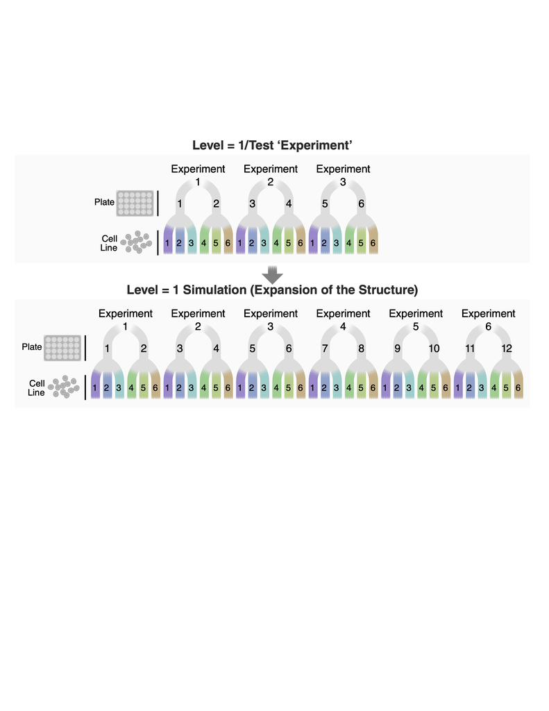

```r
template_dir="~/Dropbox (Gladstone)/calcPower f1000_manuscript/Final_paper_materials/Revisions/Older Versions Tutorial/tutorial_session3/"

##load the design
design <- readDesign(paste0(template_dir,"design_cell_assay_sim1.json"))
##load the probability model
model <- readProbabilityModel(paste0(template_dir,"prob_model_sim1.json"))
##load the relevant power parameters
power_param <- readPowerParams(paste0(template_dir,"power_param_sim1.json"))

print(design)
```

```
## An object of class "RMeDesign"
## Slot "response_column":
## [1] "cell_size2"
##
## Slot "covariate":
## NULL
##
## Slot "condition_column":
## [1] "classification"
##
## Slot "condition_is_categorical":
## [1] TRUE
##
## Slot "experimental_columns":
## [1] "experiment" "line"
##
## Slot "crossed_columns":
## [1] "line"
##
## Slot "total_column":
## NULL
##
## Slot "outlier_alpha":
## [1] 0.05
##
## Slot "na_action":
## [1] "complete"
##
## Slot "include_interaction":
## [1] FALSE
##
## Slot "random_slope_variable":
## NULL
```

```r
print(model)
```

```
## An object of class "ProbabilityModel"
## Slot "error_is_non_normal":
## [1] FALSE
##
## Slot "family_p":
## NULL
```

```r
print(power_param)
```

```
## An object of class "PowerParams"
## Slot "target_columns":
## [1] "experiment"
##
## Slot "power_curve":
## [1] 1
##
## Slot "nsimn":
## [1] 10
##
## Slot "levels":
## [1] 1
##
## Slot "max_size":
## NULL
##
## Slot "alpha":
## [1] 0.05
##
## Slot "breaks":
## NULL
##
## Slot "effect_size":
## NULL
##
## Slot "icc":
## NULL
```

```r
##calculate power
power_res <- calculatePower(RMeDPower_data1, design, model, power_param)
```

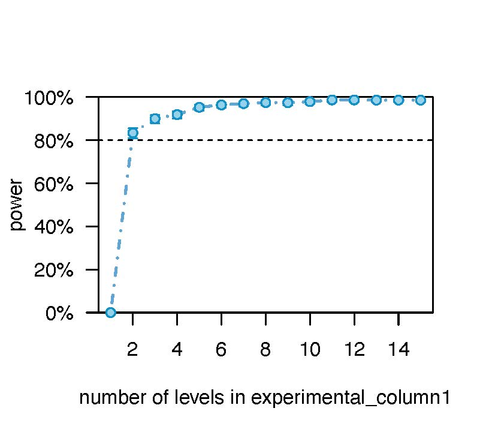

Figure 6: Sim1

In a similar context, users can evaluate power for a given number of experiments. To do this, we assign a value corresponding to the number of experiments to ‘max_size’ and set ‘power_curve’ to 0. We can set the ‘output’ variable to specify the output file name.

```r
template_dir="~/Dropbox (Gladstone)/calcPower f1000_manuscript/Final_paper_materials/Revisions/Older Versions Tutorial/tutorial_session3/"

##load the design
design <- readDesign(paste0(template_dir,"design_cell_assay_sim3.json"))
##load the probability model
model <- readProbabilityModel(paste0(template_dir,"prob_model_sim3.json"))
##load the relevant power parameters
power_param <- readPowerParams(paste0(template_dir,"power_param_sim3.json"))

print(power_param)
```

```
## An object of class "PowerParams"
## Slot "target_columns":
## [1] "experiment"
##
## Slot "power_curve":
## [1] 0
##
## Slot "nsimn":
## [1] 10
##
## Slot "levels":
## [1] 1
##
## Slot "max_size":
## [1] 15
##
## Slot "alpha":
## [1] 0.05
##
## Slot "breaks":
## NULL
##
## Slot "effect_size":
## NULL
##
## Slot "icc":
## NULL
```

[output not shown]

Alternatively, a user can assess how increasing the number of plates per experiment affects power. In the case where there are two experiments that each contain two plates, the user can double the number of plates used per experiment. In this way, the user can simulate how the statistical power changes as a result of increasing the number of plates used per experiment rather than increasing the number of experimental batches (Figure 7).

Figure 7: Example of RMeDPower’s simulation of plate variability for ‘plate’ power analysis  
If level=1 is set, RMeDPower simulates new plates by inheriting the experimental design structure from the existing data.

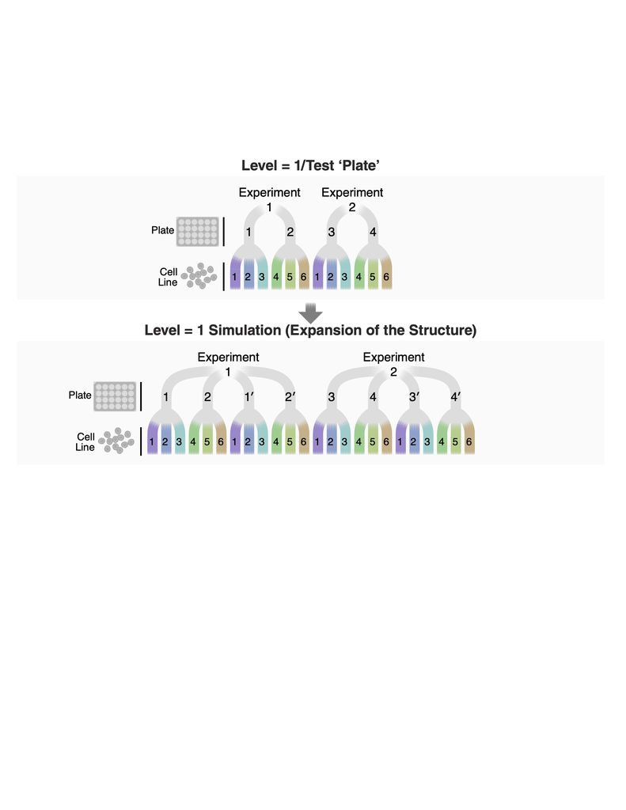

In a third example, a user can examine the effect of expanding the number of cell lines within each experiment affects power (Figure 8). This would capture the effect of increasing the number of cells assayed as a consequence of having more cell lines.

Figure 8: Example of RMeDPower’s simulation of cell line variability for ‘cell line’ power analysis  
If level=1 is set, RMeDPower simulates new cell lines by inheriting the experimental design structure from the existing data.

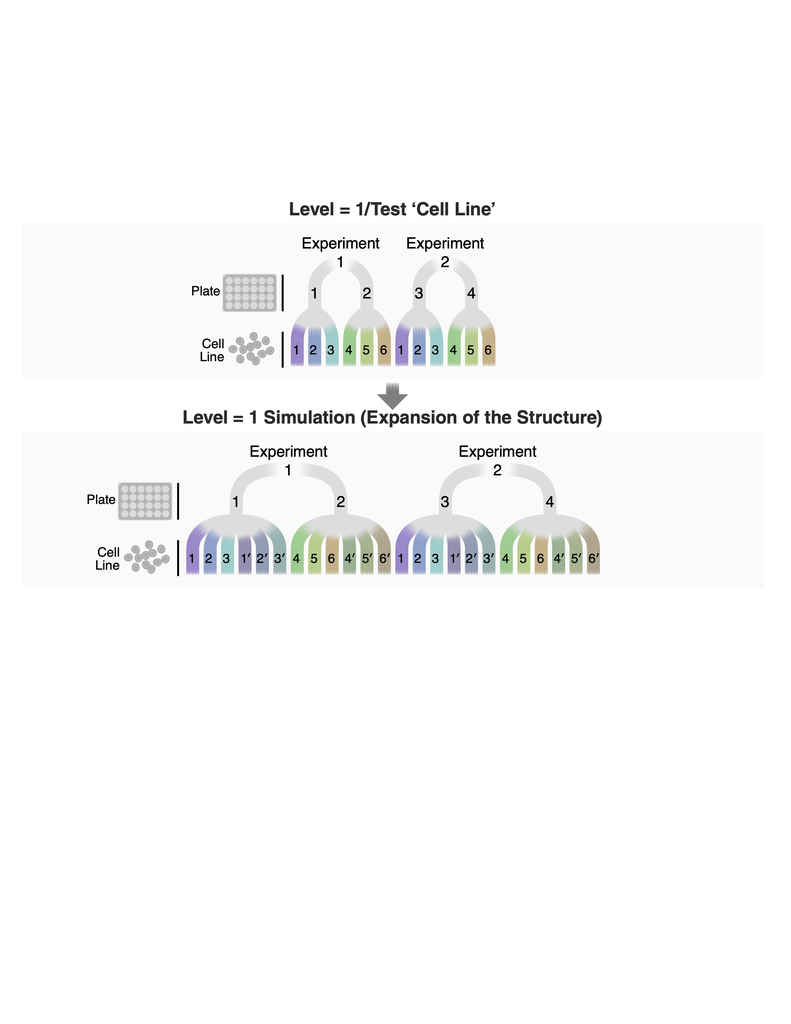

Alternatively, one might want to assess the effect of increasing the total number of cells by increasing the number of cells per cell line (Figure 9).

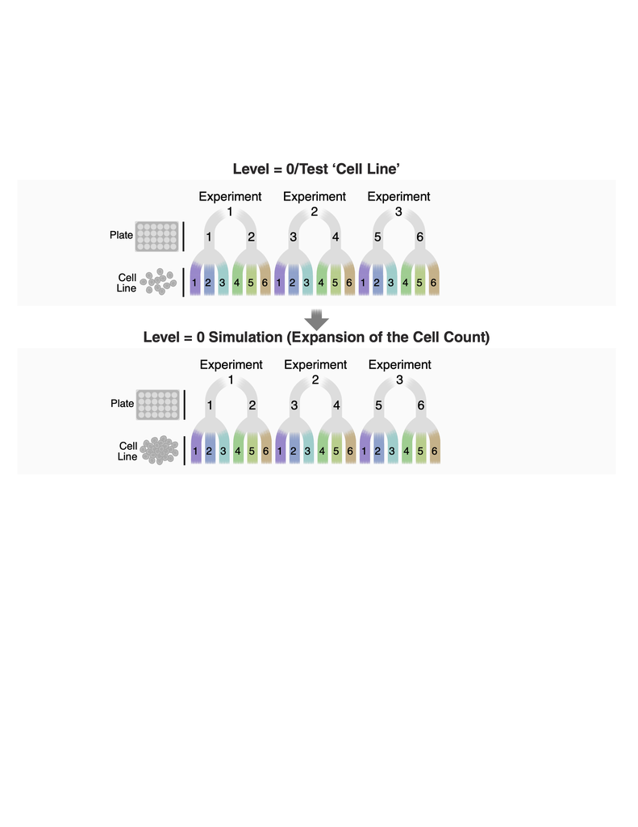

Tables 1-3, in addition to the figures, show the change in cell number after variable expansion in experiment, plate or cell line, especially when the cell distribution is asymmetric. A user may want to examine the power of increasing the total number of cells measured from each experimental variable per experiment. For example, if there are 12 cells per cell line on plate 1, doubling the number of cells from each plate will result in assessing the effect in twice the number of cells per cell line, even if the number of experiments and cell lines remain the same (Figure 10).

Figure 10: Example of RMeDPower’s simulation of a sample size increase for ‘plate’ power analysis  
If level=0 is set, RMeDPower multiplies the number of cells per plate by M/N, where N is the maximum number of cells per plate and M is a value assigned to the parameter ‘max_size’.

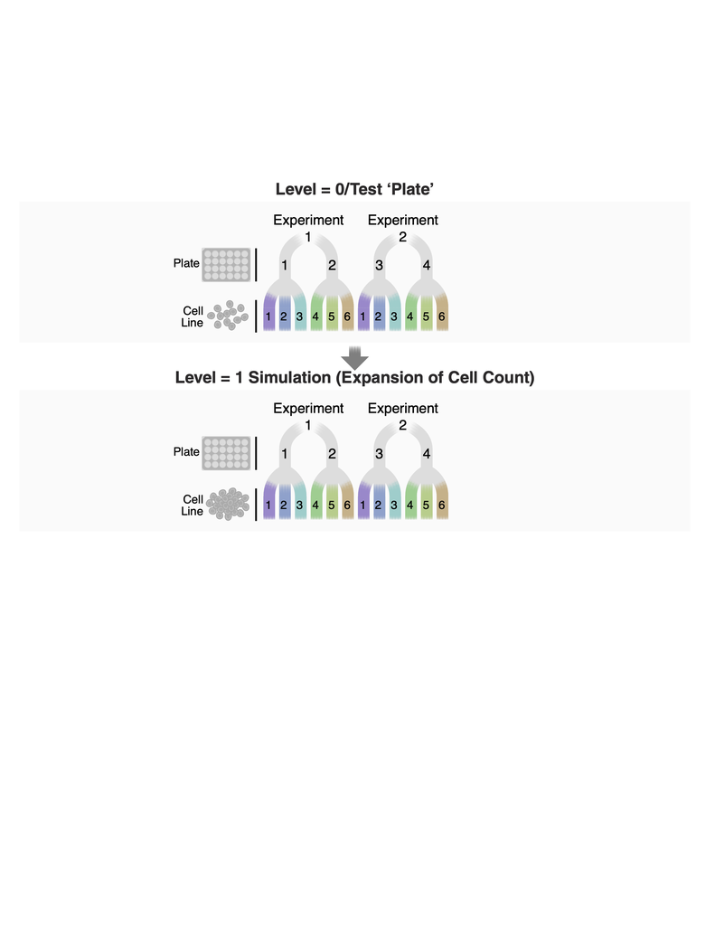

Table 1: Example of changes in cell counts in a simulation of experimental batch variability (A) Original data structure and (B) changed data structure after simulation. Simulation based on level=1 keeps the same structure and increases the number of experiments. This describes the situation where the pilot study involved 2 experiments, in the first experiment two cell lines are used with 3 and 6 cells assayed, respectively, and in the second experiment only 3 cells from the first experiment are assayed.

| (A) | Cell line 1 | Cell line 2 |
| --- | --- | --- |
| Exp 1 | 3 | 6 |
| Exp 2 | 3 | 0 |
| (B) | Cell line 1 | Cell line2 |
| Exp 1 | 3 | 6 |
| Exp 2 | 3 | 0 |
| Exp 3 | 3 | 6 |
| Exp 4 | 3 | 0 |

Table 2: Example of changes in cell counts in a simulation of plate variability (A) Original data structure and (B) changed data structure after simulation. Simulation based on level=1 keeps the same structure and increases the number of plates.

| (A) | Cell line 1 | Cell line 2 |
| --- | --- | --- |
| Plate 1 | 4 | 5 |
| Plate 2 | 2 | 0 |
| (B) | Cell line 1 | Cell line 2 |
| Plate 1 | 4 | 5 |
| Plate 2 | 2 | 0 |
| Plate 1’ | 4 | 5 |
| Plate 2’ | 2 | 0 |

Table 3: Example of changes in cell counts in a simulation of cell line variability (A) Original data structure and (B) changed data structure after simulation. If level=1 is set, RMeDPower simulates new cell lines by inheriting the experimental design structure from the existing data. An example of a simulation in tabular format shows the change in the number of cells per cell line and experiment after simulation. Simulation based on level=1 keeps the same structure and increases the number of cell lines.

| (A) | Cell line 1 | Cell line 2 |  |  |  |  |
| --- | --- | --- | --- | --- | --- | --- |
| Exp 1 | 3 | 6 |  |  |  |  |
| Exp 2 | 3 | 0 |  |  |  |  |
| (B) | Cell line 1a | Cell line 2a | Cell line 1b | Cell line 2b | Cell line 1c | Cell line 2c |
| Exp 1 | 3 | 6 | 3 | 6 | 3 | 6 |
| Exp 2 | 3 | 0 | 3 | 0 | 3 | 0 |

Expansion results for plates and cell lines may differ if cells are asymmetrically distributed in different settings. Tables 4 and 5 show the different results users can get in an asymmetric distributed cell scenario. This type of variable expansion can be accomplished by setting ‘level=0’ in the calculate_power function.

Table 4: Example of plate-based cell count expansion simulation (A) Original data structure and (B) changed data structure after simulation. The simulation is based on level=0 which results in increased number of cells per plate.

| (A) | Cell line 1 | Cell line2 |
| --- | --- | --- |
| Plate 1 | 3 | 6 |
| Plate 2 | 3 | 0 |
| (B) | Cell line 1 | Cell line 2 |
| Plate 1 | 6 | 12 |
| Plate 2 | 6 | 0 |

Table 5: Example of cell line-based cell count expansion simulation (A) Original data structure and (B) changed data structure after simulation. An example of a simulation in tabular format shows the change in the number of cells per cell line and experiment after simulation. The simulation is based on level=0 which results in an increased number of cells per cell line.

| (A) | Cell line 1 | Cell line 2 |
| --- | --- | --- |
| Exp 1 | 3 | 6 |
| Exp 2 | 3 | 0 |
| (B) | Cell line 1 | Cell line 2 |
| Exp 1 | 9 | 18 |
| Exp 2 | 9 | 0 |

```r
template_dir="~/Dropbox (Gladstone)/calcPower f1000_manuscript/Final_paper_materials/Revisions/Older Versions Tutorial/tutorial_session3/"

##load the design
design <- readDesign(paste0(template_dir,"design_cell_assay_sim2.json"))
##load the probability model
model <- readProbabilityModel(paste0(template_dir,"prob_model_sim2.json"))
##load the relevant power parameters
power_param <- readPowerParams(paste0(template_dir,"power_param_sim2.json"))

print(power_param)
```

```
## An object of class "PowerParams"
## Slot "target_columns":
## [1] "line"
##
## Slot "power_curve":
## [1] 1
##
## Slot "nsimn":
## [1] 10
##
## Slot "levels":
## [1] 0
##
## Slot "max_size":
## [1] 700
##
## Slot "alpha":
## [1] 0.05
##
## Slot "breaks":
## NULL
##
## Slot "effect_size":
## NULL
##
## Slot "icc":
## NULL
```

```r
##calculate power
power_res <- calculatePower(RMeDPower_data1, design, model, power_param)
```

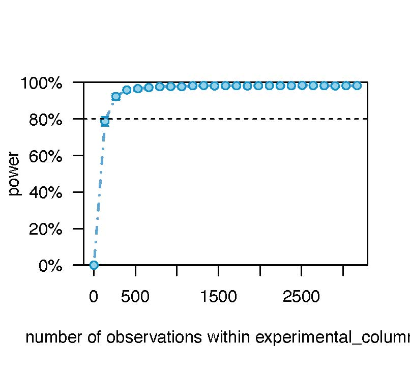

Figure 11: Sim2

```r
template_dir="~/Dropbox (Gladstone)/calcPower f1000_manuscript/Final_paper_materials/Revisions/Older Versions Tutorial/tutorial_session3/"

##load the design
design <- readDesign(paste0(template_dir,"design_cell_assay_sim5.json"))
##load the probability model
model <- readProbabilityModel(paste0(template_dir,"prob_model_sim5.json"))
##load the relevant power parameters
power_param <- readPowerParams(paste0(template_dir,"power_param_sim5.json"))

print(power_param)
```

```
## An object of class "PowerParams"
## Slot "target_columns":
## [1] "experiment" "line"
##
## Slot "power_curve":
## [1] 1
##
## Slot "nsimn":
## [1] 10
##
## Slot "levels":
## [1] 1 0
##
## Slot "max_size":
## [1]   9 142
##
## Slot "alpha":
## [1] 0.05
##
## Slot "breaks":
## NULL
##
## Slot "effect_size":
## NULL
##
## Slot "icc":
## NULL
```

```r
##calculate power
power_res <- calculatePower(RMeDPower_data1, design, model, power_param)
```

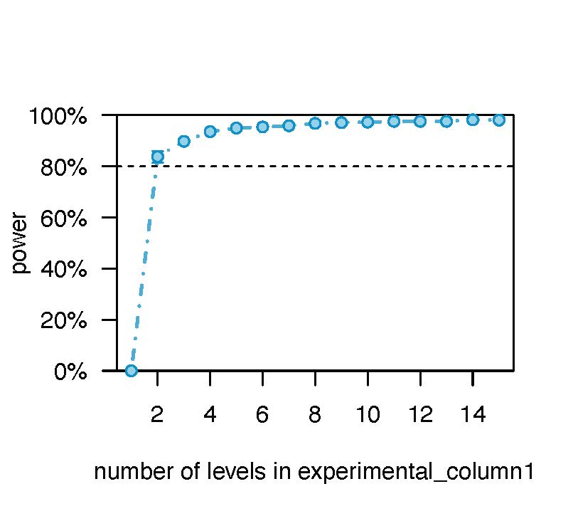

Figure 12: Sim5

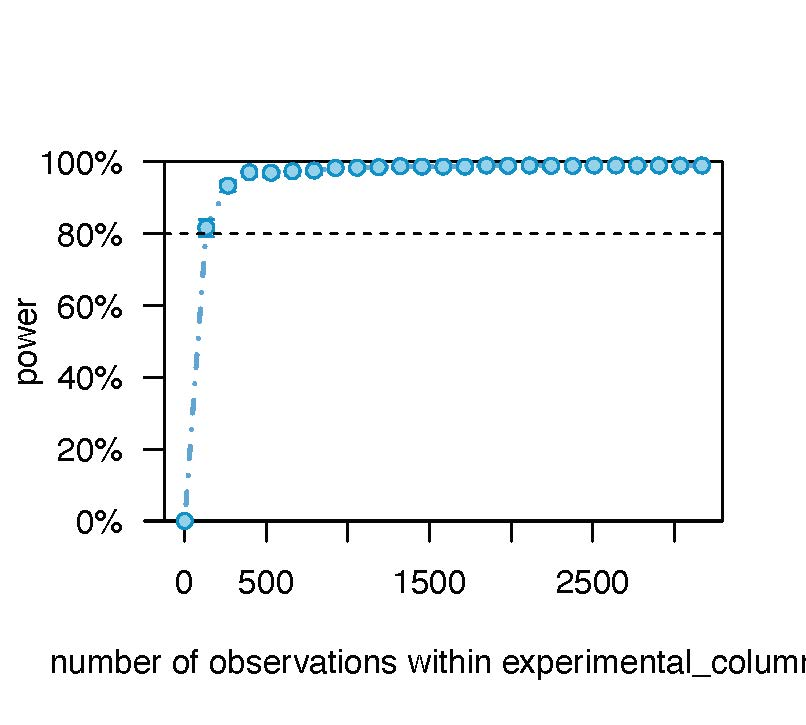

Figure 13: Sim5

Our power simulations depend on the variance components estimated from the input dataset. However, in some cases there may not be enough data to estimate the variance component. For example, the pilot data might have only a single category for ‘experimental batch’, ‘plate’ or ‘line’. When this occurs, the user needs to provide ICC values. These values can be estimated from another dataset for which the variance components are assumed to be similar to those inherent for the new response being considered in the input dataset. ICC can be estimated by taking the ratio between the variance estimates using the following formula:

where V_i represents the variance of the random effect linked to experimental variable (e.g., experimental batch, plate or cell-line) i, and epsilon represents the variance of the residual error. S represents all the modeled sources of variability of the response under consideration. We will test this scenario using the example RMeDPower_data2 with only single experiment and cell line. To test power in scenarios with varying number of experiments, we set the ‘icc’ parameter to 0.8, 0.05, 0.05. (Figure14).

```r
template_dir="~/Dropbox (Gladstone)/calcPower f1000_manuscript/Final_paper_materials/Revisions/Older Versions Tutorial/tutorial_session3/"

##load the design
design <- readDesign(paste0(template_dir,"design_cell_assay_sim6.json"))
##load the probability model
model <- readProbabilityModel(paste0(template_dir,"prob_model_sim6.json"))
##load the relevant power parameters
power_param <- readPowerParams(paste0(template_dir,"power_param_sim6.json"))

#print(design)
#print(model)
print(power_param)
```

```
## An object of class "PowerParams"
## Slot "target_columns":
## [1] "experiment"
##
## Slot "power_curve":
## [1] 1
##
## Slot "nsimn":
## [1] 10
##
## Slot "levels":
## [1] 1
##
## Slot "max_size":
## NULL
##
## Slot "alpha":
## [1] 0.05
##
## Slot "breaks":
## NULL
##
## Slot "effect_size":
## NULL
##
## Slot "icc":
## [1] 0.80 0.05 0.05
```

```r
##calculate power
power_res <- calculatePower(RMeDPower_data2, design, model, power_param)
```

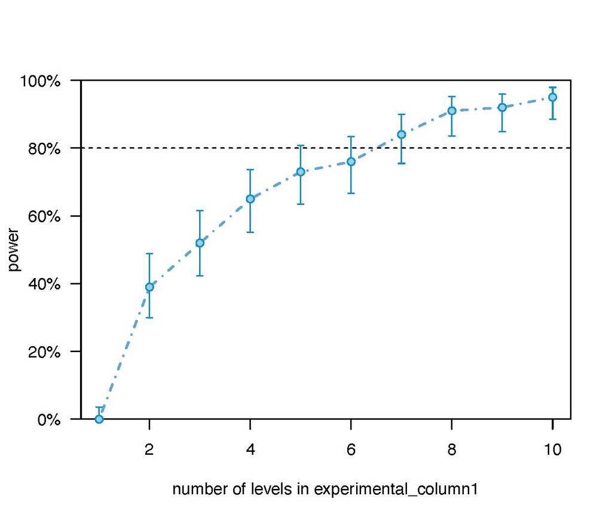

Figure 14: Sim6